```r
library(tidyverse)
```

```r
library(ggplot2)
library(BSDA)
```

# Hypothesis Testing

Before, you studied many parameters of an experiment and probabilities of possible outcomes. But very often analysts want to answer a question with only two choices.

**Example: Coin toss**

A person wants to test that a penny has exactly a 50% chance of landing on heads, the null hypothesis would be that 50% is correct, and the alternative hypothesis would be that 50% is not correct.

A random sample of 100 coin flips is taken, and it was found that the 100 coin flips were distributed as 40 heads and 60 tails. The analyst would assume that a penny does not have a 50% chance of landing on heads, so it is not a “fair coin”.

But what if there were 48 heads and 52 tails?

The null and alternative hypotheses are two competing claims that researchers weigh evidence for and against using a statistical test:

- Null hypothesis (H<sub>0</sub>): There’s no effect in the population.
- Alternative hypothesis (H<sub>1</sub>): There’s an effect in the population.

The *null* and *alternative* are always claims about the population. That’s because the goal of hypothesis testing is to make inferences about a population based on a sample. Often, we infer whether there’s an effect in the population by looking at differences between groups or relationships between variables in the sample. It’s critical for your research to write strong hypotheses.

The null hypothesis is the claim that there’s no effect in the population.

If the sample provides enough evidence against the claim that there’s no effect in the population, then we can reject the null hypothesis. Otherwise, we fail to reject the null hypothesis.

**Example: Legal trial**

The population is accused of the “crime”, and the sample is the criminal evidence. In the United States and many other countries, a person accused of a crime is assumed to be innocent until proven guilty. Similarly, we start by assuming the population is “innocent” of having an effect.

In other words, the null hypothesis (i.e., that there is no effect) is assumed to be true until the sample provides enough evidence to reject it.

*Null hypotheses* often include phrases such as “no effect,” “no difference,” or “no relationship.” When written in mathematical terms, they always include an equality (usually =, but sometimes ≥ or ≤).

*Alternative hypotheses* often include phrases such as “an effect,” “a difference,” or “a relationship.” When alternative hypotheses are written in mathematical terms, they always include an inequality (usually ≠, but sometimes < or >).

**Example: Tooth flossing**

Does tooth flossing affect the number of cavities?

We make an experiment and calculate the mean number of cavities per person between the flossing group (µ<sub>1</sub>) and the non-flossing group (µ<sub>2</sub>).

- H<sub>0</sub>: Tooth flossing has **no effect** on the number of cavities (µ<sub>1</sub> = µ<sub>2</sub> in the population).
- H<sub>1</sub>: Tooth flossing has an **effect** on the number of cavities (µ<sub>1</sub> ≠ µ<sub>2</sub> in the population).

## Task 1

Express H<sub>0</sub> and H<sub>1</sub> symbolically for testing each claim below:

1. The mean annual starting salary for computer science majors is greater than $70,000.
2. The standard deviation for human body temperatures equals 0.34 °C.
3. The proportion of people that suffer from diabetes in America is less than 9%.
4. The standard deviation of duration times (in seconds) of the Old Faithful geyser is less than 40 seconds.

# Approaches to Hypothesis Testing

## 1. Using a Confidence Interval

1. Identify the null hypothesis and the alternative hypothesis (and decide which is the claim).
2. Ensure any necessary assumptions are met for the test to be conducted.
3. Construct a confidence interval with a confidence level of (1−α).
4. If the hypothesized population parameter falls outside of the confidence interval, conclude that the null hypothesis should be rejected based on what we saw. If it falls within the confidence interval, conclude that we fail to reject the null hypothesis as a result of what we saw.
5. Make an inference.

## 2. Using Critical Values

1. Identify the null hypothesis and the alternative hypothesis (and decide which is the claim).
2. Ensure any necessary assumptions are met for the test to be conducted.
3. Find the test statistic.
4. Find the critical values associated with the significance level (α) and the alternative hypothesis to establish the rejection region in the distribution.
5. If the test statistic falls in the rejection region, conclude that the null hypothesis should be rejected based on what we saw. If not, conclude that we fail to reject the null hypothesis as a result of what we saw.
6. Make an inference.

**Note:** Review Chi-squared test from Lab 11.

## 3. Using p-values

1. Identify the null hypothesis and the alternative hypothesis (and decide which is the claim).
2. Ensure any necessary assumptions are met for the test to be conducted.
3. Find the test statistic.
4. Find the p-value associated with the test statistic as it relates to the alternative hypothesis.
5. Compare the p-value with the significance level (α). If p < α, conclude that the null hypothesis should be rejected based on what we saw. If not, conclude that we fail to reject the null hypothesis as a result of what we saw.
6. Make an inference.

**Note:** Compare this approach with Exercise 8 from Lab 11.

# One Sample Z-test

**N.B.** Z-test can be applied only to normally distributed data.

## Two-sided hypothesis testing

When we are interested in testing whether the population mean μ is equal to a certain known value μ<sub>0</sub>, we use two-sided z-test.

- H<sub>0</sub>: μ = μ<sub>0</sub>
- H<sub>1</sub>: μ ≠ μ<sub>0</sub>

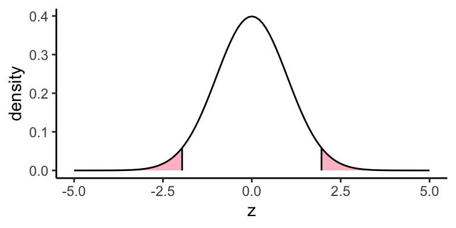

Critical values of population mean are estimated from Normal distribution: $P(t > z) = \alpha/2$.

## Task 2

Let’s suppose that a student is interesting in estimating how many memes their professors know and love. So they go to class, and every time a professor uses a new meme, they write it down. After a year of classes, the student has recorded the following meme counts, where each count corresponds to a single class they took:

3, 7, 11, 0, 7, 0, 4, 5, 6, 2

The student talks to some other students who’ve done similar studies and determines that σ=2 is a reasonable value for the standard deviation of this distribution.

Let’s test the null hypothesis that, on average, professors know 3 memes. That is

$$H_0: \mu = 3
\qquad
H_1: \mu \ne 3$$

First we need to calculate z-statistic:

$$z = {
{\bar{x} - \mu_0}
\over
{\sigma / \sqrt{n}}
}$$

```r
x <- c(3, 7, 11, 0, 7, 0, 4, 5, 6, 2)
sigma <- 2

n <- length(x)
z_stat <- (mean(x) - 3) / (sigma / sqrt(n))
z_stat
```

```
## [1] 2.371708
```

Now, find the critical values z for the significance level α = 5%

```r
alpha <- 0.05
qnorm(p=alpha/2, lower.tail=T)
```

```
## [1] -1.959964
```

```r
qnorm(p=alpha/2, lower.tail=F)
```

```
## [1] 1.959964
```

If we want to know the probability of μ = 3, then we need to calculate

$$\text{p-value} = P(z < z_{stat}) + P(z > z_{stat})$$

```r
pnorm(-2.37) + (1 - pnorm(2.37))
```

```
## [1] 0.01778809
```

```r
pnorm(-2.37) * 2
```

```
## [1] 0.01778809
```

The p-value is the probability that the null hypothesis is **true**.

## One-sided hypothesis testing

One-side test is similar to the two-sided but is used when the null hypothesis is less or equal, or greater or equal to some value.

$$H_0: \mu \le 3 \qquad H_1: \mu > 3$$

the p-value is given by $P(z > 2.37)$.

```r
1 - pnorm(2.37)
```

```
## [1] 0.008894043
```

For the reverse test

$$H_0: \mu \ge 3 \qquad H_1: \mu < 3$$

the p-value is given by $P(z < 2.37)$.

```r
pnorm(2.37)
```

```
## [1] 0.991106
```

Pay attention, that the significance level (α) is divided by 2 in the two-tailed test, but is used in whole in the one-tailed test.

## Exercise #3

Read the dataset from “data/high-school.csv”. We will work with TV variable.

1. Use p-value test to check could the mean value be equal to 14.3.
2. Use z-test to check the claim μ ≠ 14.1.
3. Use p-value test to check that μ < 14.5.
4. Use z-test to check that μ ≤ 14.3.

```r
#question 1
data <- read_csv("/Users/ozodbekadkhamov/DataspellProjects/hypothesis-testing/data/high-school.csv", show_col_types=F)

m <- mean(data$TV)  # 14.2
n <- nrow(data)     # 50069
s <- sd(data$TV)
z_stat <- (m - 14.3) / (s / sqrt(n))  # -1.52
pnorm(z_stat) * 2
```

```
## [1] 0.1286927
```

```r
# question 2
z_stat <- (m - 14.1) / (s / sqrt(n))
alpha <- 0.05
z <- qnorm(alpha/2, lower.tail=F)

z_stat
```

```
## [1] 2.769061
```

```r
z
```

```
## [1] 1.959964
```

```r
# question 3
z_stat <- (m - 14.5) / (s / sqrt(n))  # -5.8
pnorm(z_stat)  # only lower tail!
```

```
## [1] 3.168429e-09
```

```r
# question 4

z_stat <- (m - 14.3) / (s / sqrt(n))
z <- qnorm(alpha, lower.tail=F)

z_stat
```

```
## [1] -1.519277
```

```r
z
```

```
## [1] 1.644854
```

## Task 4

Suppose the IQ in a certain population is normally distributed with a mean of μ = 100 and standard deviation of σ = 15. A scientist wants to know if a new medication affects IQ levels, so she recruits 20 patients to use it for one month and records their IQ levels at the end of the month.

```r
# IQ levels for 20 patients after 1 month
iq_data <- c(88, 92, 94, 94, 96, 97, 97, 97, 99, 99, 105,
             109, 109, 109, 110, 112, 112, 113, 114, 115)
```

Find the mean value, z statistics and the corresponding critical values (α=5%).

```r
m0 <- 100
s <- 15
n <- length(iq_data)
m <- mean(iq_data)
z_stat <- (m - m0) / (s / sqrt(n))
z_crit <- qnorm(p=0.05/2, lower.tail=F)

m
```

```
## [1] 103.05
```

```r
z_stat
```

```
## [1] 0.9093343
```

```r
z_crit
```

```
## [1] 1.959964
```

Library BSDA provides a special function for hypothesis testing.

```r
library(BSDA)

z.test(
  iq_data, mu=100, sigma.x=15,
  alternative="two.sided",
  conf.level=0.95
)
```

```
##
##  One-sample z-Test
##
## data:  iq_data
## z = 0.90933, p-value = 0.3632
## alternative hypothesis: true mean is not equal to 100
## 95 percent confidence interval:
##   96.47608 109.62392
## sample estimates:
## mean of x
##    103.05
```

## Task 5

Repeat the Exercise #3 using `z.test` function.

Read the dataset from “data/high-school.csv”. We will work with TV variable.

1. Use p-value test to check could the mean value be equal to 14.3.
2. Use z-test to check the claim μ ≠ 14.1.
3. Use p-value test to check that μ < 14.5.
4. Use z-test to check that μ ≤ 14.3.

```r
data <- read_csv("/Users/ozodbekadkhamov/DataspellProjects/hypothesis-testing/data/high-school.csv", show_col_types=F)
s <- sd(data$TV)

z.test(data$TV, mu=14.3, sigma.x=s,
       alternative="two.sided", conf.level=0.95)
```

```
##
##  One-sample z-Test
##
## data:  data$TV
## z = -1.5193, p-value = 0.1287
## alternative hypothesis: true mean is not equal to 14.3
## 95 percent confidence interval:
##  14.13773 14.32055
## sample estimates:
## mean of x
##  14.22914
```

```r
z.test(data$TV, mu=14.3, sigma.x=s,
       alternative="two.sided", conf.level=0.95)
```

```
##
##  One-sample z-Test
##
## data:  data$TV
## z = -1.5193, p-value = 0.1287
## alternative hypothesis: true mean is not equal to 14.3
## 95 percent confidence interval:
##  14.13773 14.32055
## sample estimates:
## mean of x
##  14.22914
```

# Two sample Z-test

A two sample z-test is used to test whether two population means are equal. So, the parameter `mu` of the function `z.test()` is the difference between two means. Usually, we assume it to be equal to 0.

## Task 6

Suppose the IQ levels among individuals in two different cities are known to be normally distributed each with population standard deviations of 15.

A scientist wants to know if the mean IQ level between individuals in city A and city B are different, so she selects a simple random sample of 20 individuals from each city and records their IQ levels.

```r
cityA = c(82, 84, 85, 89, 91, 91, 92, 94, 99, 99, 105,
          109, 109, 109, 110, 112, 112, 113, 114, 114)

cityB = c(90, 91, 91, 91, 95, 95, 99, 99, 108, 109, 109,
          114, 115, 116, 117, 117, 128, 129, 130, 133)
```

```r
z.test(x=cityA, y=cityB, mu=0, sigma.x=15, sigma.y=15)
```

```
##
##  Two-sample z-Test
##
## data:  cityA and cityB
## z = -1.7182, p-value = 0.08577
## alternative hypothesis: true difference in means is not equal to 0
## 95 percent confidence interval:
##  -17.446925   1.146925
## sample estimates:
## mean of x mean of y
##    100.65    108.80
```

# T-test

In order to use z-test, one needs to know the population standard deviation σ. Very often we don’t have this information. However, the central limit theorem provides a way to infer it from the standard error of sample:

$$s = {σ \over \sqrt{n}}$$

T-test uses this equation to draw σ, simplifying the hypothesis testing but at the cost additional uncertainty, which is reflected in the heavier tails of the t-distribution compared to the normal distribution.

## Task 7

Let’s return to Exercise #2 estimating how many memes professors know, and test is this number equal to 3.

```r
x <- c(3, 7, 11, 0, 7, 0, 4, 5, 6, 2)
```

Calculate t-statistics and the corresponding p-value from t-distribution.

$$t = {{\bar{x} - \mu_0}\over{s / \sqrt{n}}}$$

```r
n <- length(x)
t_stat <- (mean(x) - 3) / (sd(x) / sqrt(n))
t_stat
```

```
## [1] 1.378916
```

```r
pt(-t_stat, df=n-1) * 2
```

```
## [1] 0.2012211
```

## T-test in R

Function `t.test()` is very similar to `z.test()` but requires less parameters.

```r
t.test(x, mu=3, alternative="two.sided")
```

```
##
##  One Sample t-test
##
## data:  x
## t = 1.3789, df = 9, p-value = 0.2012
## alternative hypothesis: true mean is not equal to 3
## 95 percent confidence interval:
##  2.0392 6.9608
## sample estimates:
## mean of x
##       4.5
```

Test two more combinations of hypotheses for the significance level 10%:

- $H_0: \mu \le 3 \qquad H_1: \mu > 3$
- $H_0: \mu \ge 3 \qquad H_1: \mu < 3$

```r
t.test(x, mu = 3, alternative = "greater", conf.level = 0.90)
```

```
##
##  One Sample t-test
##
## data:  x
## t = 1.3789, df = 9, p-value = 0.1006
## alternative hypothesis: true mean is greater than 3
## 90 percent confidence interval:
##  2.995526      Inf
## sample estimates:
## mean of x
##       4.5
```

## Task 8

The average 1-ounce chocolate chip cookie contains 110 calories. A random sample of 15 different brands of cookies resulted in the following calorie amounts.

```r
x <- c(100, 160, 125, 100, 150, 150, 160, 140, 185, 135, 125, 120, 155, 110, 145)
```

At the 0.01 significance level, is there sufficient evidence that the average caloric content is greater than 110 calories? Use the critical value method.

```r
t.test(x, mu = 3, alternative = "less", conf.level = 0.90)
```

```
##
##  One Sample t-test
##
## data:  x
## t = 21.572, df = 14, p-value = 1
## alternative hypothesis: true mean is less than 3
## 90 percent confidence interval:
##      -Inf 145.7091
## sample estimates:
## mean of x
##  137.3333
```

# Sample size

## Task 9

A random sample of the birth weights of 186 babies has a mean of 3103 g and a standard deviation of 696 g. These babies are born to mothers who did not use cocaine during their pregnancy.

1. Construct a 95% confidence interval estimate of the mean birth weight for all such babies. 95% Confidence Interval: $\bar{x} ± E$, where $E = t_{α/2} \cdot s / \sqrt{n}$.
2. Compare the confidence interval from part b) to this confidence interval obtained for birth weights (in grams) of babies born to mothers who used cocaine during pregnancy: 2608 < μ < 2792.

Does cocaine use appear to affect the birth weight of a baby?

```r
n <- 186
m <- 3103
s <- 696

t_crit <- qt(0.05/2, df=n-1, lower.tail=F)
e <- t_crit * s / sqrt(n)

sprintf("(%.1f, %.1f)", m-e, m+e)
```

```
## [1] "(3002.3, 3203.7)"
```

## Task 10

Below is a random sample of times for a swimming event.

```r
x <- c(154.61, 175.62, 158.03, 175.82, 164.22, 176.47, 165.19, 176.58, 165.64,
       177.68, 168.62, 180.33, 170.08, 183.63, 173.17, 185.71, 174.48, 186.49)
```

1. Find a 95% confidence interval for the mean time for this event.
2. How large a sample is needed to find the mean time for the swimming event within 0.2 seconds with 95% confidence?

This time, we will use the function `t.test`

```r
t.test(x, conf.level = 0.95)
```

```
##
##  One Sample t-test
##
## data:  x
## t = 82.134, df = 17, p-value < 2.2e-16
## alternative hypothesis: true mean is not equal to 0
## 95 percent confidence interval:
##  168.4679 177.3510
## sample estimates:
## mean of x
##  172.9094
```

What is the value of the marginal error?

```r
res <- t.test(x, conf.level = 0.95)
(res$conf.int[2] - res$conf.int[1]) / 2
```

```
## [1] 4.441592
```

In order to reduce E to 0.2 seconds we need to increase the sample size

$$n = \left ( {
{z_{α/2} \cdot σ} \over {E}
} \right ) ^ 2$$

where σ can be approximated by the standard deviation of sample.

```r
z_crit <- qnorm(0.05/2)
(z_crit * sd(x) / 0.2)^2
```

```
## [1] 7661.203
```

# More practice

## Task 11

A pasta company wants to determine the average amount of macaroni they are putting in a one-pound box. The weights (in grams) of a sample of 14 boxes is given below.

Test the claim that the mean weight of a box is equal to 454 grams (1 pound = 454 grams). Use the t-test with α=1%.

```r
boxes <- c(460, 462, 458, 466, 457, 455, 459, 457, 458, 460, 453, 459, 464, 461)
t.test(boxes, mu=454, alternative="two.sided", conf.level=0.01)
```

```
##
##  One Sample t-test
##
## data:  boxes
## t = 5.7368, df = 13, p-value = 6.859e-05
## alternative hypothesis: true mean is not equal to 454
## 1 percent confidence interval:
##  459.2027 459.2259
## sample estimates:
## mean of x
##  459.2143
```

## Task 12

Listed below are speeds (mi/h) of randomly selected vehicles measured on a section of highway on a weekday afternoon. Use a 95% confidence level to test the claim that the mean speed is greater than 65 mi/h.

```r
speed <- c(61, 64, 65, 65, 66, 66, 67, 67, 67, 68, 69, 69, 70, 73, 74, 88)
t.test(speed, mu=65, alternative="greater", conf.level=0.95)
```

```
##
##  One Sample t-test
##
## data:  speed
## t = 2.4283, df = 15, p-value = 0.01411
## alternative hypothesis: true mean is greater than 65
## 95 percent confidence interval:
##  66.02541      Inf
## sample estimates:
## mean of x
##   68.6875
```

## Task 13

Hoping to attract more shoppers downtown, a city builds a new public parking garage in the central business district. The city plans to pay for the structure through parking fees. During a two-month period (44 weekdays), daily fees collected averaged $125, with a standard deviation of $15. The consultant who advised the city on this project predicted that parking revenues would average $130 per day. Test this prediction using the confidence interval method at significance level 0.10.

```r
alpha <- 0.10
n <- 44
m <- 125
s <- 15

t_crit <- qt(alpha/2, df=n-1, lower.tail=F)
e <- t_crit * s / sqrt(n)

sprintf("(%.1f, %.1f)", m-e, m+e)
```

```
## [1] "(121.2, 128.8)"
```

## Task 14

When 16 seventeen-year-old women were randomly selected and tested with an aerobics test, the mean of their scores was found to be 37.9 with a sample standard deviation of 7.3. Construct both a 90% confidence interval and a 99% confidence interval for the mean. Write out the meaning of your findings.

```r
n <- 16
m <- 37.9
s <- 7.3

t_crit <- qt(0.1/2, df=n-1, lower.tail=F)
e1 <- t_crit * s / sqrt(n)

t_crit <- qt(0.01/2, df=n-1, lower.tail=F)
e2 <- t_crit * s / sqrt(n)

sprintf("(%.1f, %.1f)", m-e1, m+e1)
```

```
## [1] "(34.7, 41.1)"
```

```r
sprintf("(%.1f, %.1f)", m-e2, m+e2)
```

```
## [1] "(32.5, 43.3)"
```

## Exercise #15

A sample of apples has weights (in grams) given below.

1. Find a 95% confidence interval for the mean weight of this kind of apple.
2. How large a sample would be needed to estimate the mean weight of these apples with 99% confidence and margin of error at most 5 grams?

```r
apples <- c(139, 169, 165, 133, 164, 150, 163, 137, 132, 134,
            105, 114, 103, 123, 111)
```

Confidence interval

```r
t.test(apples, conf.level=0.95)
```

```
##
##  One Sample t-test
##
## data:  apples
## t = 23.569, df = 14, p-value = 1.149e-12
## alternative hypothesis: true mean is not equal to 0
## 95 percent confidence interval:
##  123.7453 148.5213
## sample estimates:
## mean of x
##  136.1333
```

Sample size

```r
z_crit <- qnorm(0.01/2)
(z_crit * sd(apples) / 5)^2
```

```
## [1] 132.8066
```